# Notebook

### Web Information Retrieval and Data Mining - Assignment 3

```
Student: Tomilin, Tristan (1492691)
```

#### Answer 1.1, Baseline (4p)

- Dense network, at least 3 layers, shaped like a pyramid
  - Last layer: 10 nodes, sigmoid.
  - Loss: categorical cross-entropy. Metric: accuracy
- No preprocessing, regularization. Get at least 70% accuracy.
- Explain design decisions. Discuss performance.
  - Does it overfit (large/growing gap between loss and val_loss)?

[output not shown]

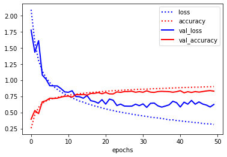

```
Model: "sequential"
_________________________________________________________________
Layer (type)                 Output Shape              Param #
=================================================================
reshape (Reshape)            (None, 3072)              0
_________________________________________________________________
dense (Dense)                (None, 512)               1573376
_________________________________________________________________
dense_1 (Dense)              (None, 256)               131328
_________________________________________________________________
dense_2 (Dense)              (None, 128)               32896
_________________________________________________________________
dense_3 (Dense)              (None, 64)                8256
_________________________________________________________________
dense_4 (Dense)              (None, 32)                2080
_________________________________________________________________
dense_5 (Dense)              (None, 10)                330
=================================================================
Total params: 1,748,266
Trainable params: 1,748,266
Non-trainable params: 0
_________________________________________________________________
None
def build_model_1_1():
  model_1_1 = Sequential()
  model_1_1.add(Reshape((target_shape,), input_shape = (32, 32, 3)))
  model_1_1.add(Dense(512, activation = relu))
  model_1_1.add(Dense(256, activation = relu))
  model_1_1.add(Dense(128, activation = relu))
  model_1_1.add(Dense(64, activation = relu))
  model_1_1.add(Dense(32, activation = relu))
  model_1_1.add(Dense(10, activation = softmax))
  model_1_1.compile(optimizer = SGD(), loss = categorical_crossentropy, metrics=['accuracy'])
  return model_1_1
```

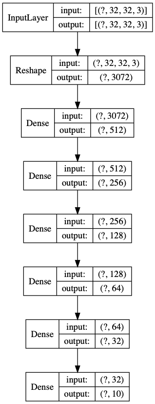

#### Answer 1.2, Preprocess (2p)

- Convert images to greyscale, other preprocessing optional.
  - Input shape should be (32,32,1)
- Explain design decisions. Is it better? Why (not)?
  - Color information is likely not so useful for classification. Greyscale makes the network smaller, less parameters to learn, less likely to overfit.

[output not shown]

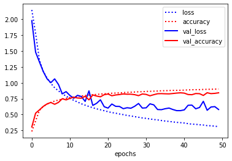

```
Model: "sequential_5"
_________________________________________________________________
Layer (type)                 Output Shape              Param #
=================================================================
reshape_4 (Reshape)          (None, 1024)              0
_________________________________________________________________
dense_27 (Dense)             (None, 512)               524800
_________________________________________________________________
dense_28 (Dense)             (None, 256)               131328
_________________________________________________________________
dense_29 (Dense)             (None, 128)               32896
_________________________________________________________________
dense_30 (Dense)             (None, 64)                8256
_________________________________________________________________
dense_31 (Dense)             (None, 32)                2080
_________________________________________________________________
dense_32 (Dense)             (None, 10)                330
=================================================================
Total params: 699,690
Trainable params: 699,690
Non-trainable params: 0
_________________________________________________________________
None
def build_model_1_2():
  model_1_2 = Sequential()
  model_1_2.add(Reshape((target_shape // 3,), input_shape = (32, 32, 1)))
  model_1_2.add(Dense(512, activation = relu))
  model_1_2.add(Dense(256, activation = relu))
  model_1_2.add(Dense(128, activation = relu))
  model_1_2.add(Dense(64, activation = relu))
  model_1_2.add(Dense(32, activation = relu))
  model_1_2.add(Dense(10, activation = softmax))
  model_1_2.compile(optimizer = SGD(), loss = categorical_crossentropy, metrics=['accuracy'])
  return model_1_2
```

#### Answer 1.3, Tune (4p)

- Regularize the model. What works best?
  - Should consider batch normalization, dropout, l1/l2 regularization (or Nesterov)
- Tune other hyperparameters (e.g. learning rate, batch size,...) as you see fit.
  - At least consider tuning learning rate, ideally also momentum, decay, other optimizers
- Explain your findings and final design decisions. Discuss the results.
  - Should be better, at least it shouldn't overfit

[output not shown]

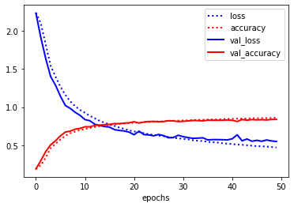

```
def build_model_1_3():
  model_1_3 = Sequential()
  model_1_3.add(Reshape((target_shape // 3,), input_shape = (32, 32, 1)))
  model_1_3.add(Dense(512, activation = relu))
  model_1_3.add(Dense(512, activation = relu))
  model_1_3.add(Dropout(0.2))
  model_1_3.add(Dense(256, activation = relu))
  model_1_3.add(Dense(256, activation = relu))
  model_1_3.add(Dropout(0.2))
  model_1_3.add(Dense(128, activation = relu))
  model_1_3.add(Dropout(0.3))
  model_1_3.add(Dense(64, activation = relu))
  model_1_3.add(Dropout(0.4))
  model_1_3.add(Dense(32, activation = relu))
  model_1_3.add(Dense(10, activation = softmax))
  model_1_3.compile(optimizer = SGD(learning_rate = learning_rate, momentum = 0.9, decay = decay_rate, nesterov = True),
                loss = categorical_crossentropy,
                metrics=['accuracy'])
  return model_1_3
```

#### Answer 2.1, ConvNet (7p)

- Build a sequential ConvNet, get at least 90% accuracy.
  - Conv2D layers, input shape (32,32,1)
  - Consider using blocks of Conv2D layers with maxpooling in between
  - Use zero-padding in Conv2D layers because the images are small
  - At least one dense hidden layer and dense output layer (sigmoid)
  - Consider adding batch normalization, dropout
  - Consider small dropout rates in beginning, larger dropout rates later in network
  - Consider other optimizers and tuning learning rate, momentum,...
- Explain what you did and why (800 chars). Is it working well?
  - Should be quite elaborate and sensible

[output not shown]

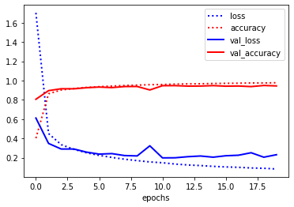

```
Model: "sequential_92"
_________________________________________________________________
Layer (type)                 Output Shape              Param #
=================================================================
conv2d_131 (Conv2D)          (None, 32, 32, 32)        2624
_________________________________________________________________
batch_normalization_137 (Bat (None, 32, 32, 32)        128
_________________________________________________________________
conv2d_132 (Conv2D)          (None, 32, 32, 32)        82976
_________________________________________________________________
batch_normalization_138 (Bat (None, 32, 32, 32)        128
_________________________________________________________________
max_pooling2d_64 (MaxPooling (None, 16, 16, 32)        0
_________________________________________________________________
dropout_220 (Dropout)        (None, 16, 16, 32)        0
_________________________________________________________________
conv2d_133 (Conv2D)          (None, 16, 16, 64)        100416
_________________________________________________________________
batch_normalization_139 (Bat (None, 16, 16, 64)        256
_________________________________________________________________
conv2d_134 (Conv2D)          (None, 16, 16, 64)        200768
_________________________________________________________________
batch_normalization_140 (Bat (None, 16, 16, 64)        256
_________________________________________________________________
max_pooling2d_65 (MaxPooling (None, 8, 8, 64)          0
_________________________________________________________________
dropout_221 (Dropout)        (None, 8, 8, 64)          0
_________________________________________________________________
conv2d_135 (Conv2D)          (None, 8, 8, 128)         204928
_________________________________________________________________
batch_normalization_141 (Bat (None, 8, 8, 128)         512
_________________________________________________________________
conv2d_136 (Conv2D)          (None, 8, 8, 128)         409728
_________________________________________________________________
batch_normalization_142 (Bat (None, 8, 8, 128)         512
_________________________________________________________________
max_pooling2d_66 (MaxPooling (None, 4, 4, 128)         0
_________________________________________________________________
dropout_222 (Dropout)        (None, 4, 4, 128)         0
_________________________________________________________________
```

[output cut: 51 more lines]

```
  model_2_1.add(BatchNormalization())
  model_2_1.add(Conv2D(256, (3, 3), activation = relu, padding = 'same'))
  model_2_1.add(BatchNormalization())
  model_2_1.add(MaxPool2D((2, 2), padding = 'same'))
  model_2_1.add(Dropout(0.5))

  model_2_1.add(Flatten())
  model_2_1.add(Dense(256, activation = relu))
  model_2_1.add(BatchNormalization())
  model_2_1.add(Dense(128, activation = relu))
  model_2_1.add(Dense(10, activation = softmax))
  model_2_1.compile(optimizer = Adam(),
                loss = categorical_crossentropy,
                metrics=['accuracy'])
  return model_2_1
```

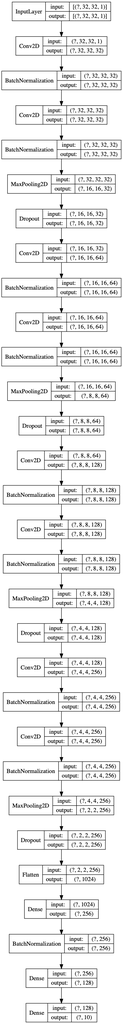

#### Answer 2.2, Data Augmentation (3p)

- Augment the preprocessed training data.
  - Use small variations (small shifts up-down, left-right) of flips becasue the images are small
  - Large shifts and rotations distort the image too much
- Explain what you did and why. Discuss the performance of the model.

[output not shown]

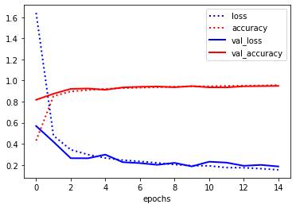

```
    datagen = ImageDataGenerator(
        rotation_range = 10,
        shear_range = 0.3,
        zoom_range = 0.1,
        fill_mode = 'nearest'
    )
```

#### Answer 3.1, Misclassifications (2p)

[output not shown]

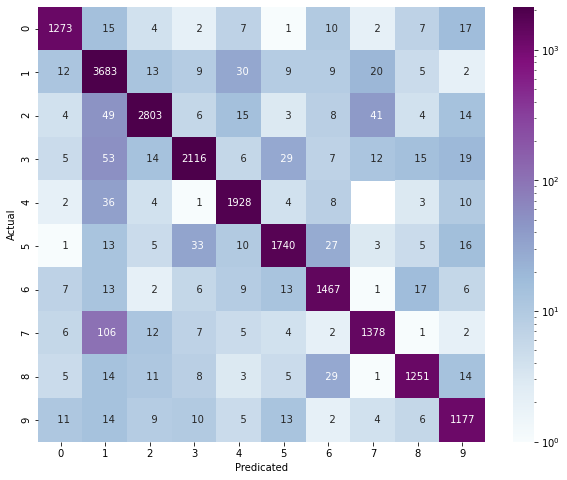

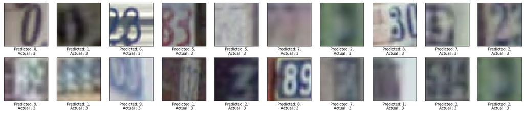

#### Answer 3.2, Activations (4p)

- Retrieve and visualize the activations for one example
- For every filter for different convolutional layers (at different depths in the network).
- Give an explanation. Is your model indeed learning something useful?
  - Should detect edges etc in first layers, higher-order object (e.g. interesting regions) in deeper layers.

[output not shown]

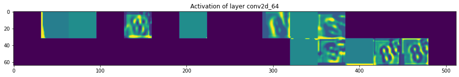

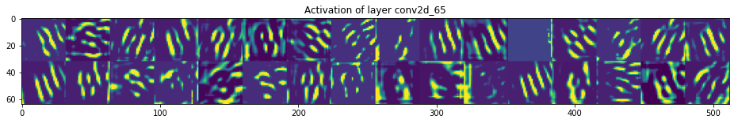

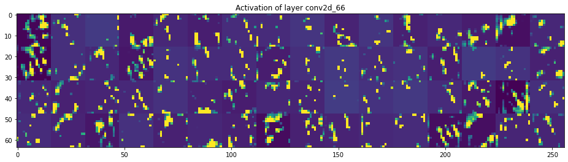

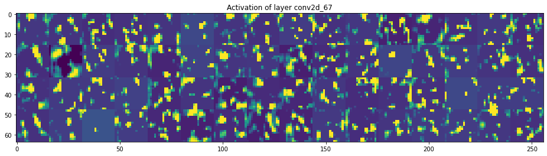

#### Answer 3.3, Class activation map (4p)

- Show a class activation map for your last convolutional layer
- Superimpose the activation map over the image, or plot side by side
  - Should make sense, detect interesting regions to classify the number

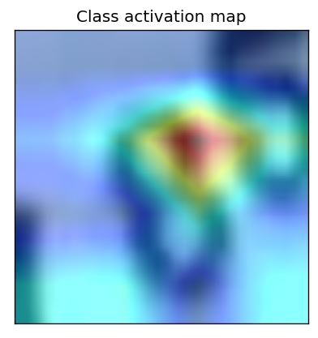

```
def plot_activation_map():
  K.clear_session()
  img_tensor = X_test_gray[0]
  img_tensor = np.expand_dims(img_tensor, axis = 0)
  model = load_model_from_file(base_dir, 'model_2_2')
  conv2d_layers = [layer for layer in model.layers if 'conv2d' in layer.name]
  last_conv_layer_output = conv2d_layers[-1].output
  filter_index = 0
  with tf.GradientTape() as tape:
    tape.watch(last_conv_layer_output)
    loss = K.mean(last_conv_layer_output[:, :, :, filter_index])
  grads = tape.gradient(loss, last_conv_layer_output)
  pooled_grads = K.mean(grads, axis = (0, 1, 2))
  iterate = K.function([model.input], [pooled_grads, last_conv_layer_output[0]])
  pooled_grads_value, conv_layer_output_value = iterate([img_tensor])
  for i in range(256):
      conv_layer_output_value[:, :, i] *= pooled_grads_value[i]
  return np.mean(conv_layer_output_value, axis = -1)
```

#### Answer 4.1, Fast feature extraction (5p)

- Import the VGG16 model, pretrained on ImageNet
- Freeze convolutional base, adds a dense layer
- Consider unfreezing the last few convolutional layers and evaluate whether that works better
  - Check if they do. It is very likely to help.
- Discuss the observed performance
  - Should get around 80% accuracy

[output not shown]

[output cut: 19 more lines]

```
  conv_base = VGG16(weights = 'imagenet', include_top = False, input_shape = (32, 32, 3))
  model_4_1 = models.Sequential()
  for layer in conv_base.layers:
    layer.trainable = layer.name.startswith('block5_conv')
    model_4_1.add(layer)
  model_4_1.add(Flatten())
  model_4_1.add(Dense(128, activation = relu, kernel_regularizer = l2(0.01), bias_regularizer = l1(0.01)))
  model_4_1.add(BatchNormalization())
  model_4_1.add(Dropout(0.5))
  model_4_1.add(Dense(10, activation = sigmoid))
  model_4_1.compile(optimizer = Adam(lr = 1e-3),
              loss = categorical_crossentropy,
              metrics=['accuracy'])
  model_4_1.summary()
  return model_4_1
```

#### Answer 4.2, Embeddings (5p)

- Generate embeddings with the trained convolutional part of model_4_1 (without the dense layer)
- Embed the training and test data and store them to disk
- Build and evaluate a pipeline on the embedded data
  - Check if pipeline makes sense (e.g. use models that can handle many dimensions)
- Describe what you did and what you observed (max 800 chars).
  - Consider different models, preprocessing, tuning, etc.
  - Check performance (see original Submission.html) when in doubt. We did not run all the evaluations because it takes too long, and the output is ill-defined.

[output not shown]

```
Running time: 18.22 seconds
Last modified: May 26, 2020
scikit-learn version: 0.23.1
```